# Probe selection for IPF lung using SPAPROS

# Environment

## load R environment

```r
library(tidyverse)
library(Seurat)
```

## Load IPF Cell Atlas data

Spapros is expecting scanpy format data with raw counts. Load based on established R workflow then convert. ### Read in GSE136831

```r
original.dir <- ('~/vcalab-files/datasets/GSE136831_IPF_Cell_Atlas/')
metadata <- read_tsv(paste0(original.dir,'GSE136831_AllCells.Samples.CellType.MetadataTable.txt.gz'))
metadata <- as.data.frame(metadata)
rownames(metadata) <- metadata$CellBarcode_Identity

features <- read_tsv(paste0(original.dir,'GSE136831_AllCells.GeneIDs.txt.gz'))
cells <- read_tsv(paste0(original.dir,'GSE136831_AllCells.cellBarcodes.txt.gz'), col_names = F)
counts <- Matrix::readMM(paste0(original.dir,'GSE136831_RawCounts_Sparse.mtx.gz'))
rownames(counts) <- features$HGNC_EnsemblAlt_GeneID
colnames(counts) <- cells$X1
```

```r
ipfatlas.cells <- CreateSeuratObject(counts=counts, meta.data=metadata)
```

```r
rm(counts,cells,features,metadata)
gc()
```

```
             used   (Mb) gc trigger    (Mb)   max used    (Mb)
Ncells    4287022  229.0    6682443   356.9    6682443   356.9
Vcells 1053056767 8034.2 3672764273 28021.0 4194266324 31999.8
```

### Standard filters

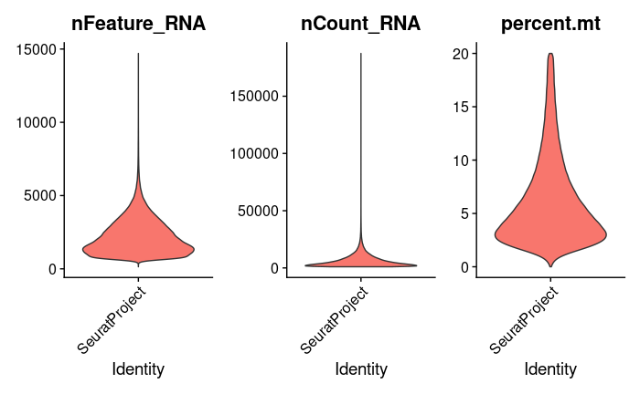

```r
ipfatlas.cells[['percent.mt']] <- PercentageFeatureSet(ipfatlas.cells, pattern='^MT-')
VlnPlot(ipfatlas.cells, features = c("nFeature_RNA", "nCount_RNA", "percent.mt"), ncol = 3, pt.size = 0)
```

```r
ipfatlas.cells <- subset(ipfatlas.cells, subset = nFeature_RNA > 200 & nFeature_RNA < 5000 & percent.mt < 10)
```

### Convert to scanpy compatible format (anndata)

This is remarkably not a solved problem but sceasy has functions for it. have to back-convert the Seurat5 object to a v3-like assay.

```r
ipfatlas.cells[['RNA']] <- as(ipfatlas.cells[['RNA']],'Assay')
sceasy::convertFormat(ipfatlas.cells, from='seurat',to='anndata', outFile = 'ipfatlas.adata')
```

```
AnnData object with n_obs × n_vars = 253424 × 45947
    obs: 'nCount_RNA', 'nFeature_RNA', 'CellBarcode_Identity', 'nUMI', 'nGene', 'CellType_Category', 'Manuscript_Identity', 'Subclass_Cell_Identity', 'Disease_Identity', 'Subject_Identity', 'Library_Identity', 'percent.mt'
    var: 'name'
```

## load python environment

Weird behavior when reticulate instantiated by other packages, therefore restart R.

```r
.rs.restartR()
```

Using the SPAPROS workflow documented by theis lab which is python/scanpy based.

```python
reticulate::repl_python()
import pandas as pd
import scanpy as sc
import spapros as sp
sc.settings.verbosity=0
sc.logging.print_header()
```

```
scanpy==1.9.6 anndata==0.10.3 umap==0.5.5 numpy==1.26.3 scipy==1.11.4 pandas==1.5.3 scikit-learn==1.1.3 statsmodels==0.14.1 igraph==0.9.11 pynndescent==0.5.11
```

```python
print(f"spapros=={sp.__version__}")
```

```
spapros==0.1.4
```

Access adata object on the python side. to avoid name conversions throughout python code, just make it “adata.” Unpredictable behavior when porting from R to python environment, so store as h5ad and read back in.

```python
adata = sc.read_h5ad('ipfatlas.adata')
adata
```

```
AnnData object with n_obs × n_vars = 253424 × 45947
    obs: 'nCount_RNA', 'nFeature_RNA', 'CellBarcode_Identity', 'nUMI', 'nGene', 'CellType_Category', 'Manuscript_Identity', 'Subclass_Cell_Identity', 'Disease_Identity', 'Subject_Identity', 'Library_Identity', 'percent.mt'
    var: 'name'
```

# SPAPROS probe selection

## Preprocess data with scanpy

Filtering has already been done on the Seurat side.

```python
sc.pp.normalize_total(adata, target_sum=10000) # 10k target matches default Seurat scale factor
sc.pp.log1p(adata)
sc.pp.highly_variable_genes(adata,flavor="cell_ranger",n_top_genes=1000)
sc.pp.pca(adata, svd_solver='lobpcg') # had issues with arpack
```

[output not shown]

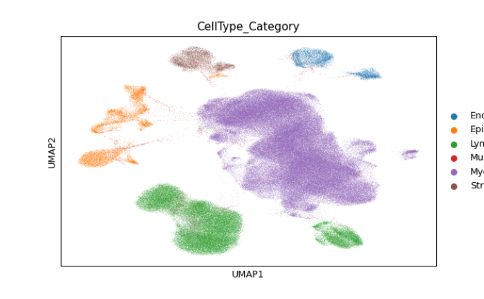

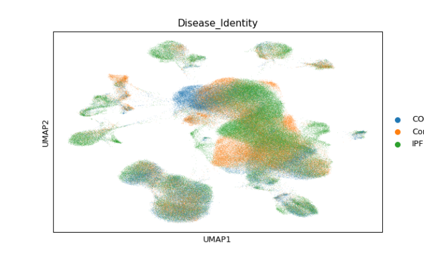

```python
sc.pp.neighbors(adata, n_neighbors=10, n_pcs=30)
sc.tl.umap(adata)
sc.pl.umap(adata, color=['CellType_Category'])
sc.pl.umap(adata, color=['Disease_Identity'])
```

## SPAPROS basic: no constraints.

Asked for 200 genes, because one imagines that various stakeholders will add another 100 for IPF subsets, and probably asthma stakeholders will add another 100 bringing total to 400. Note that this dataset includes normal lung and COPD lung.

```python
selector = sp.se.ProbesetSelector(adata, n=200, celltype_key="Manuscript_Identity", verbosity=0, save_dir=None)
```

```
Note: The following celltypes' test set sizes for forest training are below min_test_n (=20):
     Ionocyte : 6
     PNEC     : 12
The genes selected for those cell types potentially don't generalize well. Find the genes for each of those cell types in self.genes_of_primary_trees after running self.select_probeset().
```

```python
selector.select_probeset()
```

[output not shown]

[output cut: 166 more lines]

### Quick summary of selected probes

What is the distribution of chosen probes among methods?

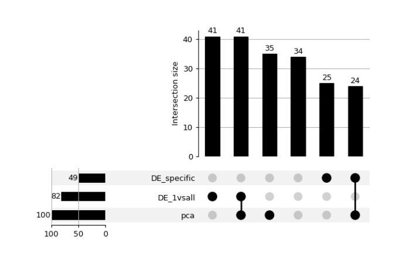

```python
selector.plot_gene_overlap()
```

```python
# list probes
selector.probeset.index[selector.probeset.selection]
```

```
Index(['TPSB2', 'CCL21', 'GRP', 'EMP2', 'HYDIN', 'MIR205HG', 'TPM2', 'ZNF385D',
       'FCN3', 'S100B',
       ...
       'COL6A2', 'CXCL5', 'TIMP3', 'AGBL4', 'ADAM19', 'BATF', 'LIMCH1',
       'SKAP1', 'CTSW', 'ABLIM1'],
      dtype='object', length=200)
```

Table of characteristics for selected probes

```python
probe_candidates = selector.probeset[selector.probeset.selection]
probe_candidates
```

```
        gene_nr  selection  ...  required_marker  required_list_marker
TPSB2         1       True  ...             True                 False
CCL21         2       True  ...             True                 False
GRP           3       True  ...             True                 False
EMP2          4       True  ...             True                 False
HYDIN         5       True  ...             True                 False
...         ...        ...  ...              ...                   ...
BATF        196       True  ...            False                 False
LIMCH1      197       True  ...            False                 False
SKAP1       198       True  ...            False                 False
CTSW        199       True  ...            False                 False
ABLIM1      200       True  ...            False                 False

[200 rows x 17 columns]
```

### Dotplots of probeset split by selection method

#### Cluster markers (DE 1vs all)

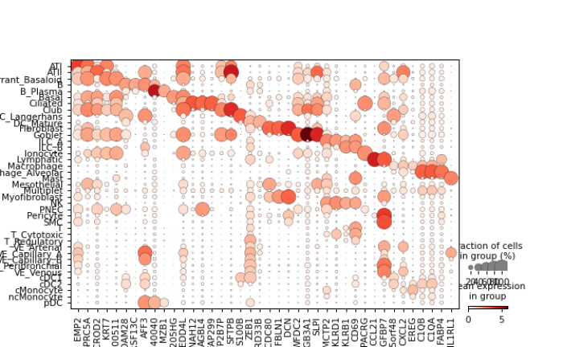

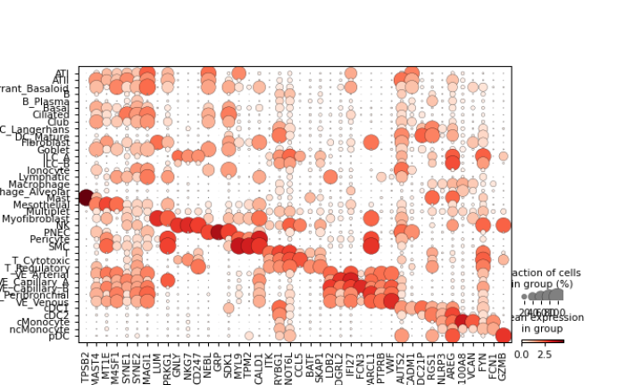

```python
probes = probe_candidates[(probe_candidates['celltypes_DE_1vsall']!='')]
probes = probes.sort_values('celltypes_DE')
sc.pl.dotplot(adata, probes.index[0:40], groupby='Manuscript_Identity', dendrogram=False)
sc.pl.dotplot(adata, probes.index[40::], groupby='Manuscript_Identity', dendrogram=False)
```

#### Nuanced cluster markers (celltypes_DE_specific)

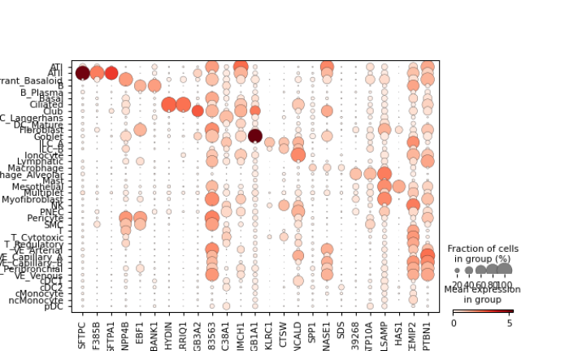

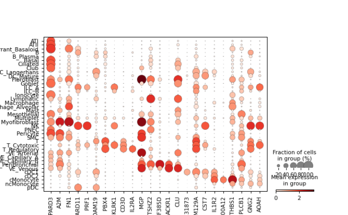

```python
probes = probe_candidates[(probe_candidates['celltypes_DE_specific']!='')]
probes = probes.sort_values('celltypes_DE')
sc.pl.dotplot(adata, probes.index[0:25], groupby='Manuscript_Identity', dendrogram=False)
sc.pl.dotplot(adata, probes.index[25::], groupby='Manuscript_Identity', dendrogram=False)
```

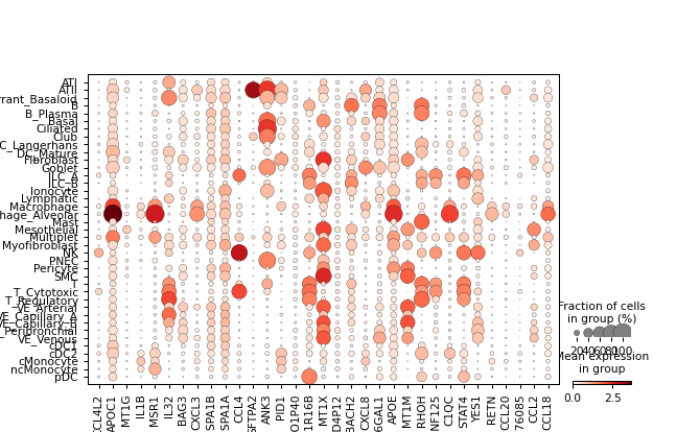

```python
probes = probe_candidates[(probe_candidates['pca_selected'])]
probes = probes.sort_values('celltypes_DE')
sc.pl.dotplot(adata, probes.index[0:33], groupby='Manuscript_Identity', dendrogram=False)
sc.pl.dotplot(adata, probes.index[33:66], groupby='Manuscript_Identity', dendrogram=False)
```

[figure not shown]

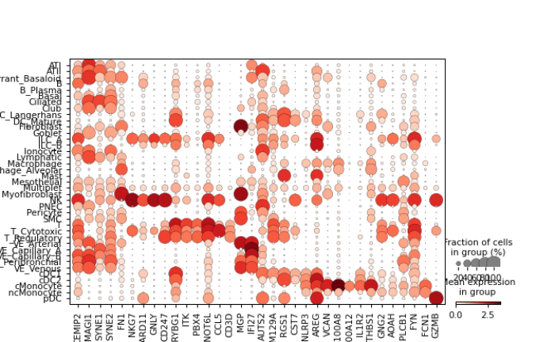

```python
sc.pl.dotplot(adata, probes.index[66::], groupby='Manuscript_Identity', dendrogram=False)
```

## SPAPROS with expression penalties

Penalties are 0 to 1, where 0 is bad and 1 is best (i.e., no penalty). Behavior of penalties seems to depend on the the source. If identified by the package, it’s a multiplier. If the source is from a manually curated list, all genes with *any* penalty is removed.

We were told by 10x that SCGB1A1 and SFTPC had too high abundance to design probes. COL1A1 is the highest single detected gene in trial runs; I am not aware of any codeword budget issues with COL1A1.

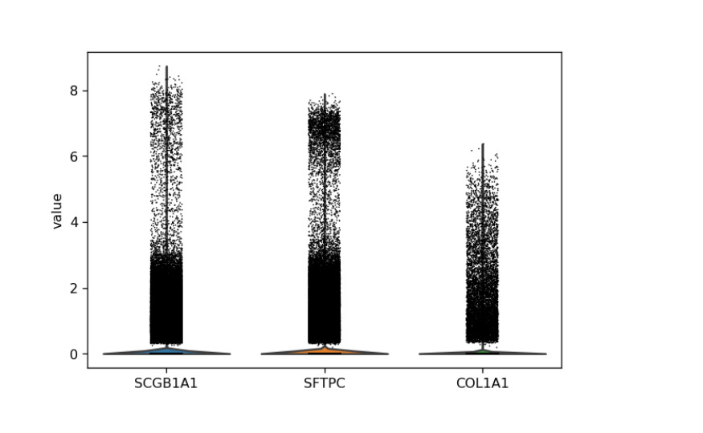

```python
sc.pl.violin(adata, ['SCGB1A1', 'SFTPC', 'COL1A1'])
```

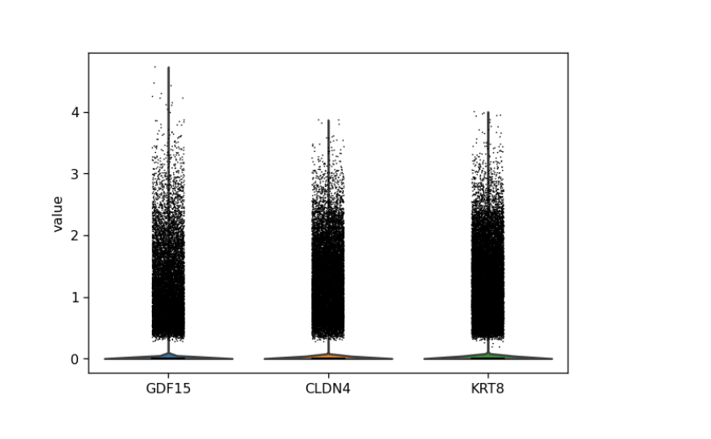

```python
sc.pl.violin(adata, ['GDF15', 'CLDN4', 'KRT8'])
```

If we wanted to be fairly aggressive, a threshold of like 1 to 6 would get us genes that are like COL1A1 or even more highly expressed. Some high performance genes like KRT8 wouldn’t necessarily be selected.

Run the selection

```python
# create an instance of the ProbesetSelector class
selector_highexpression = sp.se.ProbesetSelector(
    adata,
    n=None,
    celltype_key="celltype",
    verbosity=1,
    save_dir=None,
    pca_penalties=["expr_penalty_lower", "expr_penalty_upper"],
    DE_penalties=["expr_penalty_lower", "expr_penalty_upper"],
    m_penalties_adata_celltypes=["expr_penalty_lower", "expr_penalty_upper"],
    m_penalties_list_celltypes=["expr_penalty_upper"],
)
```

```python
selector_highexpression.select_probeset()
```

# Probeset performance evaluation within SPAPROS

Set up evaluation.

```python
evaluator = sp.ev.ProbesetEvaluator(adata, verbosity=0, results_dir=None)
```

#### Reference: trial lung panel

```python
xenium_panel1_genes = pd.read_csv('Xenium_panel_order_08_10_23.csv')['Gene']
```

```r
evaluator.evaluate_probeset(xenium_panel1_genes, set_id="Xenium Lung Trial")
```

```r
evaluator.evaluate_probeset(probes.index, set_id="SPAPROS basic")
```